# Exploratory Data Analysis for Insurance Agent NILL Prediction

## Introduction

This notebook contains the exploratory data analysis (EDA) for the Data Storm v6.0 competition. The goal is to understand patterns in insurance agent data to predict and prevent agents from going "NILL" (not selling any policies in the next month).

We'll explore:

1. Key metrics and distributions in the dataset
2. Sales patterns by month and identification of unexpected performance changes
3. Multivariate analysis of numerical features
4. Individual agent trajectory analysis
5. Innovative insights from the data

Our analysis will inform the development of predictive models and agent intervention strategies.

```python
# Import necessary libraries
import pandas as pd
import numpy as np
import matplotlib.pyplot as plt
import seaborn as sns
%matplotlib inline
plt.style.use('fivethirtyeight')
sns.set(style="whitegrid")

# Load datasets
train_df = pd.read_csv('dataset/train_storming_round.csv')
test_df = pd.read_csv('dataset/test_storming_round.csv')

# Display basic information
print(f"Training data shape: {train_df.shape}")
print(f"Testing data shape: {test_df.shape}")

# Show the first few rows
print("\nSample of training data:")
train_df.head()
```

```
Training data shape: (15308, 23)
Testing data shape: (914, 23)

Sample of training data:
```

|  | row_id | agent_code | agent_age | agent_join_month | first_policy_sold_month | year_month | unique_proposals_last_7_days | unique_proposals_last_15_days | unique_proposals_last_21_days | unique_proposal | ... | unique_quotations | unique_customers_last_7_days | unique_customers_last_15_days | unique_customers_last_21_days | unique_customers | new_policy_count | ANBP_value | net_income | number_of_policy_holders | number_of_cash_payment_policies |
| --- | --- | --- | --- | --- | --- | --- | --- | --- | --- | --- | --- | --- | --- | --- | --- | --- | --- | --- | --- | --- | --- |
| 0 | 1 | 455ca878 | 45 | 2/1/2021 | 9/1/2023 | 1/1/2023 | 3 | 6 | 2 | 12 | ... | 9 | 3 | 4 | 8 | 15 | 0 | 0 | 93313 | 30 | 162 |
| 1 | 2 | c823ce77 | 48 | 4/1/2022 | 2/1/2024 | 1/1/2023 | 1 | 4 | 12 | 21 | ... | 14 | 4 | 3 | 10 | 17 | 25 | 1071450 | 164804 | 0 | 175 |
| 2 | 3 | 62154055 | 53 | 5/1/2020 | 9/1/2023 | 1/1/2023 | 3 | 5 | 5 | 17 | ... | 14 | 3 | 7 | 11 | 21 | 26 | 1601210 | 426690 | 84 | 78 |
| 3 | 4 | c58bfa6e | 44 | 7/1/2019 | 3/1/2022 | 1/1/2023 | 1 | 0 | 12 | 17 | ... | 11 | 2 | 2 | 9 | 13 | 18 | 283230 | 47793 | 39 | 144 |
| 4 | 5 | b1e5f770 | 20 | 9/1/2020 | 2/1/2023 | 1/1/2023 | 0 | 6 | 10 | 17 | ... | 13 | 3 | 10 | 6 | 19 | 20 | 1957680 | 562239 | 19 | 40 |

5 rows × 23 columns

```python
# Convert date columns
date_columns = ['agent_join_month', 'first_policy_sold_month', 'year_month']
for col in date_columns:
    train_df[col] = pd.to_datetime(train_df[col])
    test_df[col] = pd.to_datetime(test_df[col])

# Display data types after conversion
print("\nData types after date conversion:")
print(train_df.dtypes)

# Check for missing values
print("\nMissing values in training data:")
print(train_df.isnull().sum())

# Summary statistics for numerical columns
print("\nSummary statistics:")
train_df.describe().T
```

```
Data types after date conversion:
row_id                                      int64
agent_code                                 object
agent_age                                   int64
agent_join_month                   datetime64[ns]
first_policy_sold_month            datetime64[ns]
year_month                         datetime64[ns]
unique_proposals_last_7_days                int64
unique_proposals_last_15_days               int64
unique_proposals_last_21_days               int64
unique_proposal                             int64
unique_quotations_last_7_days               int64
unique_quotations_last_15_days              int64
unique_quotations_last_21_days              int64
unique_quotations                           int64
unique_customers_last_7_days                int64
unique_customers_last_15_days               int64
unique_customers_last_21_days               int64
unique_customers                            int64
new_policy_count                            int64
ANBP_value                                  int64
net_income                                  int64
number_of_policy_holders                    int64
number_of_cash_payment_policies             int64
dtype: object

Missing values in training data:
row_id                             0
agent_code                         0
agent_age                          0
agent_join_month                   0
first_policy_sold_month            0
year_month                         0
unique_proposals_last_7_days       0
unique_proposals_last_15_days      0
unique_proposals_last_21_days      0
unique_proposal                    0
unique_quotations_last_7_days      0
unique_quotations_last_15_days     0
unique_quotations_last_21_days     0
unique_quotations                  0
unique_customers_last_7_days       0
unique_customers_last_15_days      0
unique_customers_last_21_days      0
unique_customers                   0
new_policy_count                   0
ANBP_value                         0
net_income                         0
number_of_policy_holders           0
number_of_cash_payment_policies    0
dtype: int64

Summary statistics:
```

|  | count | mean | min | 25% | 50% | 75% | max | std |
| --- | --- | --- | --- | --- | --- | --- | --- | --- |
| row_id | 15308.0 | 7654.5 | 1.0 | 3827.75 | 7654.5 | 11481.25 | 15308.0 | 4419.183296 |
| agent_age | 15308.0 | 40.585772 | 20.0 | 31.0 | 41.0 | 51.0 | 60.0 | 11.688204 |
| agent_join_month | 15308 | 2021-05-23 01:43:05.941991168 | 2019-04-01 00:00:00 | 2020-03-01 00:00:00 | 2021-05-01 00:00:00 | 2022-07-01 00:00:00 | 2024-07-01 00:00:00 | NaN |
| first_policy_sold_month | 15308 | 2023-04-24 01:41:52.568591616 | 2022-01-01 00:00:00 | 2022-10-01 00:00:00 | 2023-06-01 00:00:00 | 2023-12-01 00:00:00 | 2024-04-01 00:00:00 | NaN |
| year_month | 15308 | 2023-11-03 05:31:24.191272704 | 2023-01-01 00:00:00 | 2023-06-01 00:00:00 | 2023-11-01 00:00:00 | 2024-04-01 00:00:00 | 2024-08-01 00:00:00 | NaN |
| unique_proposals_last_7_days | 15308.0 | 1.491246 | 0.0 | 0.0 | 1.0 | 2.0 | 3.0 | 1.119554 |
| unique_proposals_last_15_days | 15308.0 | 2.991116 | 0.0 | 1.0 | 3.0 | 5.0 | 6.0 | 2.001613 |
| unique_proposals_last_21_days | 15308.0 | 10.045728 | 0.0 | 5.0 | 10.0 | 15.0 | 20.0 | 6.037296 |
| unique_proposal | 15308.0 | 17.516527 | 1.0 | 12.0 | 17.0 | 23.0 | 34.0 | 6.616954 |
| unique_quotations_last_7_days | 15308.0 | 1.989679 | 0.0 | 1.0 | 2.0 | 3.0 | 4.0 | 1.420996 |
| unique_quotations_last_15_days | 15308.0 | 2.996538 | 0.0 | 1.0 | 3.0 | 5.0 | 6.0 | 2.004386 |
| unique_quotations_last_21_days | 15308.0 | 4.469624 | 0.0 | 2.0 | 4.0 | 7.0 | 9.0 | 2.875329 |
| unique_quotations | 15308.0 | 13.922394 | 1.0 | 11.0 | 14.0 | 17.0 | 32.0 | 4.663777 |
| unique_customers_last_7_days | 15308.0 | 2.995493 | 0.0 | 2.0 | 3.0 | 4.0 | 6.0 | 1.644117 |
| unique_customers_last_15_days | 15308.0 | 4.997714 | 0.0 | 3.0 | 5.0 | 7.0 | 10.0 | 2.438918 |
| unique_customers_last_21_days | 15308.0 | 7.500523 | 0.0 | 5.0 | 8.0 | 10.0 | 15.0 | 3.468597 |
| unique_customers | 15308.0 | 15.493729 | 1.0 | 12.0 | 15.0 | 19.0 | 31.0 | 4.542321 |
| new_policy_count | 15308.0 | 20.26999 | 0.0 | 15.0 | 21.0 | 27.0 | 42.0 | 9.541693 |
| ANBP_value | 15308.0 | 1025337.788673 | 0.0 | 347323.75 | 903144.5 | 1560699.5 | 3933840.0 | 805498.862741 |
| net_income | 15308.0 | 228041.39156 | 1160.0 | 92825.0 | 189974.0 | 321744.75 | 1140237.0 | 173667.104775 |
| number_of_policy_holders | 15308.0 | 30.968317 | 0.0 | 12.0 | 28.0 | 48.0 | 116.0 | 24.621933 |
| number_of_cash_payment_policies | 15308.0 | 101.180886 | 0.0 | 38.0 | 90.0 | 152.0 | 378.0 | 75.323464 |

## Target Variable Creation: Predicting NILL Status

In this competition, we need to predict whether an agent will go "NILL" (sell zero policies) in the following month. To analyze this, we'll create a target variable where:

- 0 = Agent goes NILL (sells no policies) next month
- 1 = Agent does NOT go NILL (sells at least one policy) next month

We'll compare each month's data with the next month's sales for the same agent.

```
Target distribution (NILL vs. non-NILL):
target_column
1    11364
0     1276
Name: count, dtype: int64

Percentage distribution:
target_column
1    89.905063
0    10.094937
Name: proportion, dtype: float64
```

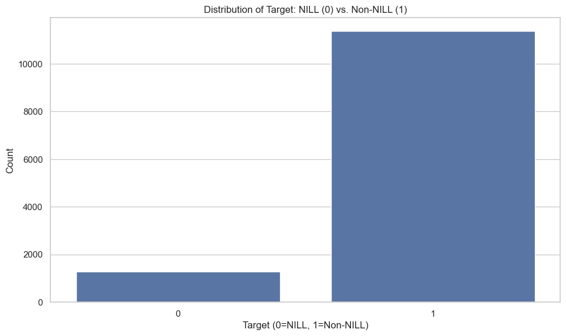

```python
# Create target variable (NILL agents)
train_df = train_df.sort_values(['agent_code', 'year_month'])
train_df['target_column'] = 0  # Default to 0 (will go NILL)

# Process each agent to create target
unique_agents = train_df['agent_code'].unique()
for agent in unique_agents:
    agent_data = train_df[train_df['agent_code'] == agent].copy()
    agent_data = agent_data.sort_values('year_month')

    # For each month, check if agent sells anything in the next month
    for i in range(len(agent_data) - 1):
        current_row_id = agent_data.iloc[i]['row_id']
        next_month_sales = agent_data.iloc[i+1]['new_policy_count']

        # If they sell anything next month, target is 1 (not NILL)
        if next_month_sales > 0:
            train_df.loc[train_df['row_id'] == current_row_id, 'target_column'] = 1

# Remove the last month for each agent (no target available)
last_month_indices = []
for agent in unique_agents:
    agent_data = train_df[train_df['agent_code'] == agent]
    if len(agent_data) > 0:
        last_month_idx = agent_data.iloc[-1].name
        last_month_indices.append(last_month_idx)

train_df = train_df.drop(last_month_indices)

# Display target distribution
print("Target distribution (NILL vs. non-NILL):")
print(train_df['target_column'].value_counts())
print("\nPercentage distribution:")
print(train_df['target_column'].value_counts(normalize=True) * 100)

# Plot target distribution
plt.figure(figsize=(10, 6))
sns.countplot(x='target_column', data=train_df)
plt.title('Distribution of Target: NILL (0) vs. Non-NILL (1)')
plt.xlabel('Target (0=NILL, 1=Non-NILL)')
plt.ylabel('Count')
plt.show()
```

## Time Series Analysis of Sales Patterns

To understand how agent performance varies over time, we'll analyze:

- Monthly trends in policy sales
- Seasonal patterns
- Identification of unusual spikes or drops in performance
- NILL rates over time

This temporal analysis will help identify critical periods when agents are more likely to go NILL.

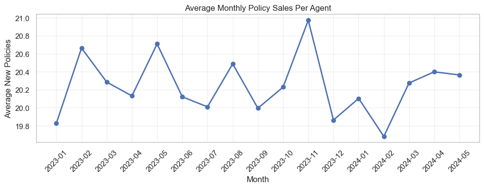

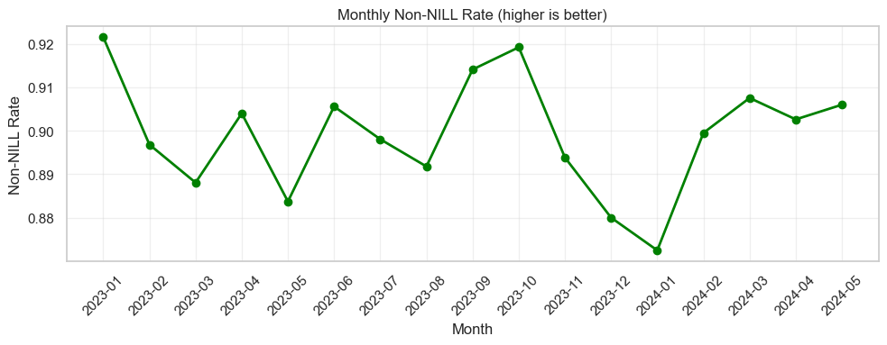

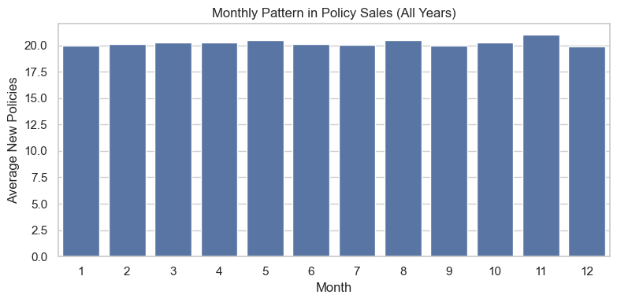

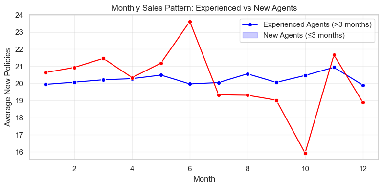

```python
# Calculate months with company for later use
train_df['months_with_company'] = ((train_df['year_month'].dt.year - train_df['agent_join_month'].dt.year) * 12 +
                                  (train_df['year_month'].dt.month - train_df['agent_join_month'].dt.month))

# Analyze monthly trends in new policy sales
monthly_sales = train_df.groupby(train_df['year_month'].dt.strftime('%Y-%m'))['new_policy_count'].mean().reset_index()

plt.figure(figsize=(10, 4))
plt.plot(monthly_sales['year_month'], monthly_sales['new_policy_count'], marker='o', linestyle='-', linewidth=2)
plt.title('Average Monthly Policy Sales Per Agent')
plt.xlabel('Month')
plt.ylabel('Average New Policies')
plt.xticks(rotation=45)
plt.grid(True, alpha=0.3)
plt.tight_layout()
plt.show()

# Analyze NILL rate by month
monthly_nill_rate = train_df.groupby(train_df['year_month'].dt.strftime('%Y-%m'))['target_column'].mean().reset_index()

plt.figure(figsize=(10, 4))
plt.plot(monthly_nill_rate['year_month'], monthly_nill_rate['target_column'], marker='o', linestyle='-', linewidth=2, color='green')
plt.title('Monthly Non-NILL Rate (higher is better)')
plt.xlabel('Month')
plt.ylabel('Non-NILL Rate')
plt.xticks(rotation=45)
plt.grid(True, alpha=0.3)
plt.tight_layout()
plt.show()

# Check for seasonality by looking at month-of-year patterns
train_df['month'] = train_df['year_month'].dt.month
monthly_pattern = train_df.groupby('month')['new_policy_count'].mean().reset_index()

plt.figure(figsize=(8, 4))
sns.barplot(x='month', y='new_policy_count', data=monthly_pattern)
plt.title('Monthly Pattern in Policy Sales (All Years)')
plt.xlabel('Month')
plt.ylabel('Average New Policies')
plt.tight_layout()
plt.show()

# Analyze if new agents have different monthly patterns
train_df['new_agent'] = (train_df['months_with_company'] <= 3).astype(int)
monthly_by_exp = train_df.groupby(['month', 'new_agent'])['new_policy_count'].mean().reset_index()

plt.figure(figsize=(8, 4))
sns.lineplot(x='month', y='new_policy_count', hue='new_agent',
             data=monthly_by_exp, marker='o',
             palette={0:'blue', 1:'red'})
plt.title('Monthly Sales Pattern: Experienced vs New Agents')
plt.xlabel('Month')
plt.ylabel('Average New Policies')
plt.legend(labels=['Experienced Agents (>3 months)', 'New Agents (≤3 months)'])
plt.grid(True, alpha=0.3)
plt.tight_layout()
plt.show()
```

## Multivariate Analysis of Features

To understand the relationships between different features and how they collectively influence agent performance, we'll analyze:

- Correlation between numerical features
- Key feature relationships with NILL prediction
- Conversion rates and their impact on performance
- Activity patterns and their relationship to sales

This will help identify the most important predictors of NILL status.

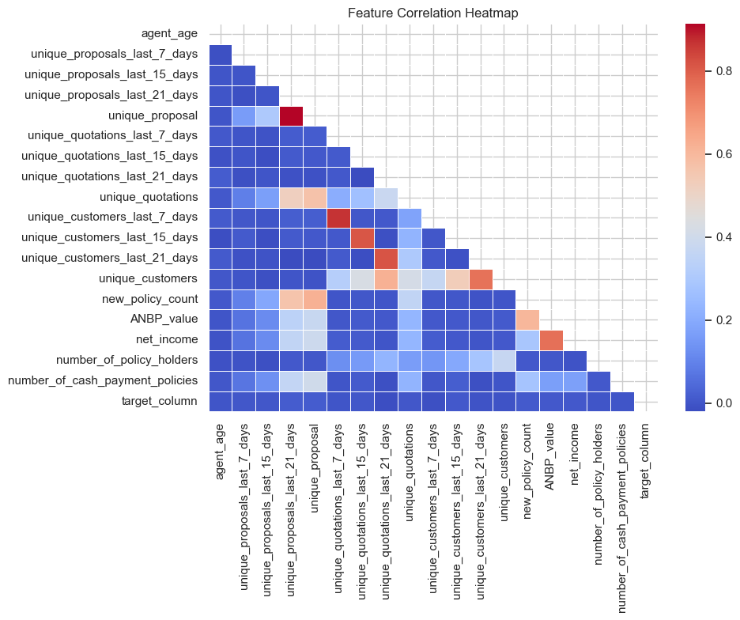

```
Top correlations with NILL prediction (target_column):
target_column                    1.000000
unique_proposals_last_21_days    0.015082
unique_proposal                  0.012646
new_policy_count                 0.009291
ANBP_value                       0.008691
unique_customers_last_15_days    0.007839
net_income                       0.007603
unique_quotations                0.004820
unique_proposals_last_15_days    0.003495
unique_proposals_last_7_days     0.002868
Name: target_column, dtype: float64

Bottom correlations with NILL prediction (target_column):
unique_proposals_last_7_days       0.002868
unique_quotations_last_15_days     0.002443
number_of_cash_payment_policies    0.001522
agent_age                          0.000871
number_of_policy_holders           0.000018
unique_quotations_last_7_days     -0.001966
unique_customers                  -0.002648
unique_customers_last_21_days     -0.003853
unique_customers_last_7_days      -0.010852
unique_quotations_last_21_days    -0.013575
Name: target_column, dtype: float64
```

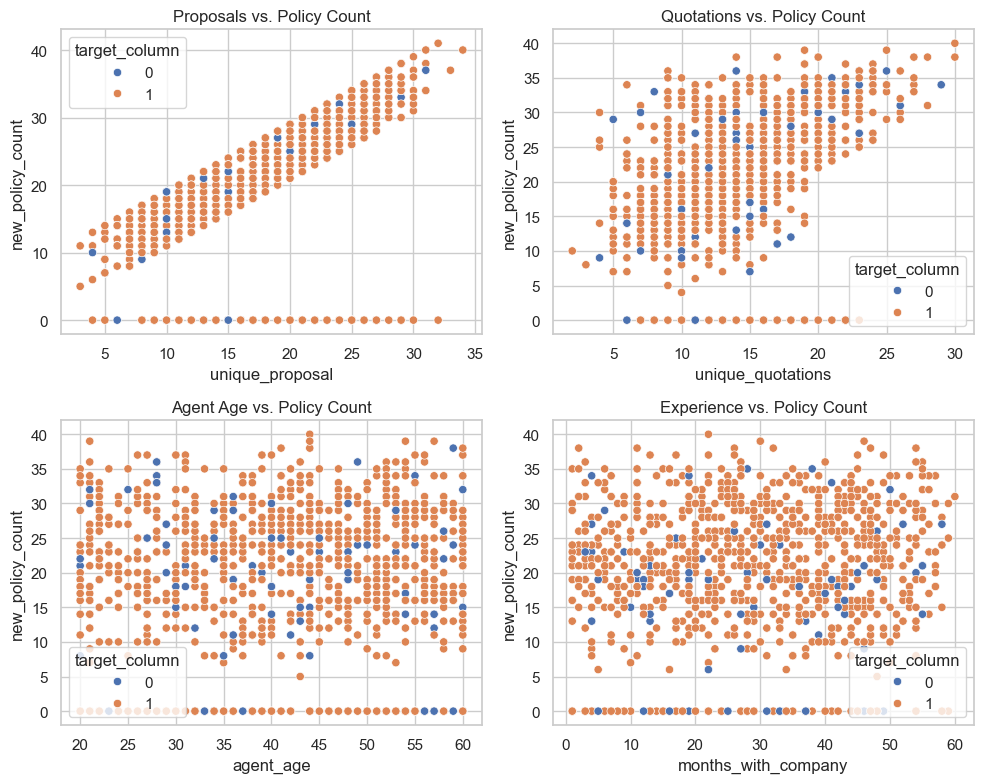

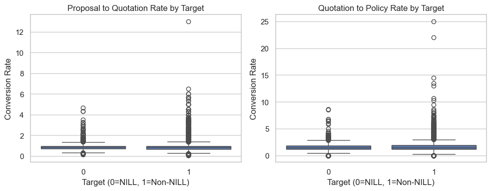

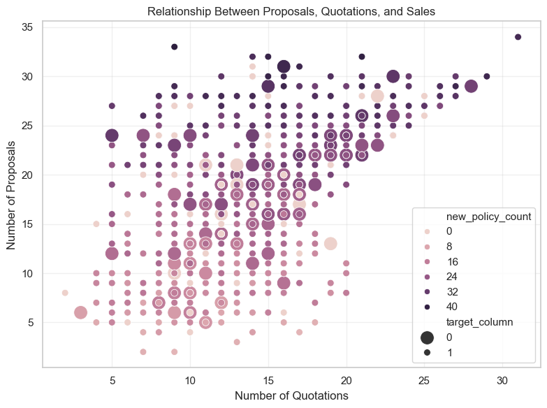

```python
# Select numeric columns for correlation
numeric_cols = [col for col in train_df.columns if train_df[col].dtype in ['int64', 'float64']]
numeric_cols = [col for col in numeric_cols if col not in ['row_id']]
correlation_df = train_df[numeric_cols].corr()

# Plot correlation heatmap
plt.figure(figsize=(10, 8))
mask = np.triu(correlation_df)
sns.heatmap(correlation_df, mask=mask, annot=False, cmap='coolwarm', linewidths=0.5)
plt.title('Feature Correlation Heatmap')
plt.tight_layout()
plt.show()

# Correlation with target variable
target_corr = correlation_df['target_column'].sort_values(ascending=False)
print("Top correlations with NILL prediction (target_column):")
print(target_corr.head(10))
print("\nBottom correlations with NILL prediction (target_column):")
print(target_corr.tail(10))

# Scatter plot of key relationships
plt.figure(figsize=(10, 8))
plt.subplot(2, 2, 1)
sns.scatterplot(x='unique_proposal', y='new_policy_count', hue='target_column', data=train_df.sample(1000))
plt.title('Proposals vs. Policy Count')

plt.subplot(2, 2, 2)
sns.scatterplot(x='unique_quotations', y='new_policy_count', hue='target_column', data=train_df.sample(1000))
plt.title('Quotations vs. Policy Count')

plt.subplot(2, 2, 3)
sns.scatterplot(x='agent_age', y='new_policy_count', hue='target_column', data=train_df.sample(1000))
plt.title('Agent Age vs. Policy Count')

plt.subplot(2, 2, 4)
sns.scatterplot(x='months_with_company', y='new_policy_count', hue='target_column',
                data=train_df[train_df['months_with_company'] <= 60].sample(1000, replace=True))
plt.title('Experience vs. Policy Count')

plt.tight_layout()
plt.show()

# Calculate conversion ratios
train_df['proposal_to_quotation'] = train_df['unique_quotations'] / np.maximum(train_df['unique_proposal'], 1)
train_df['quotation_to_policy'] = train_df['new_policy_count'] / np.maximum(train_df['unique_quotations'], 1)

# Visualize conversion rates
plt.figure(figsize=(10, 4))
plt.subplot(1, 2, 1)
sns.boxplot(x='target_column', y='proposal_to_quotation', data=train_df)
plt.title('Proposal to Quotation Rate by Target')
plt.ylabel('Conversion Rate')
plt.xlabel('Target (0=NILL, 1=Non-NILL)')

plt.subplot(1, 2, 2)
sns.boxplot(x='target_column', y='quotation_to_policy', data=train_df)
plt.title('Quotation to Policy Rate by Target')
plt.ylabel('Conversion Rate')
plt.xlabel('Target (0=NILL, 1=Non-NILL)')

plt.tight_layout()
plt.show()

# Analyze combined activities
plt.figure(figsize=(8, 6))
sns.scatterplot(x='unique_quotations', y='unique_proposal',
                hue='new_policy_count', size='target_column',
                sizes=(50, 200), data=train_df.sample(1000))
plt.title('Relationship Between Proposals, Quotations, and Sales')
plt.xlabel('Number of Quotations')
plt.ylabel('Number of Proposals')
plt.grid(True, alpha=0.3)
plt.tight_layout()
plt.show()
```

## Agent Trajectory Analysis

To understand how individual agents' performance evolves over time, we'll analyze:

- Performance trajectories for representative agents
- Comparison of high-performers vs. NILL-prone agents
- Early indicators of future NILL status
- Critical transition periods in agent careers

This will help identify early warning signs of NILL risk and understand agent development patterns.

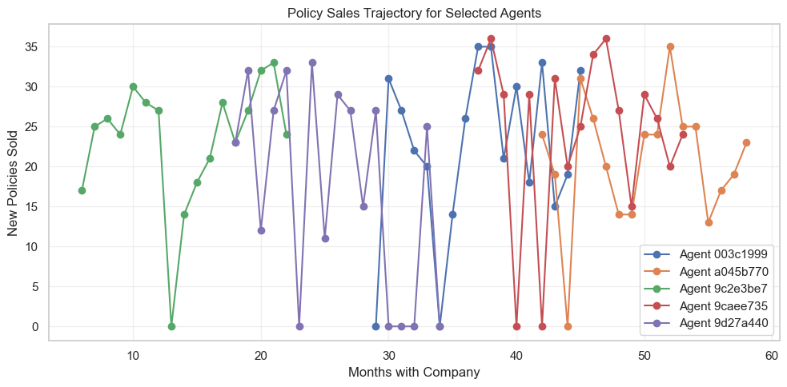

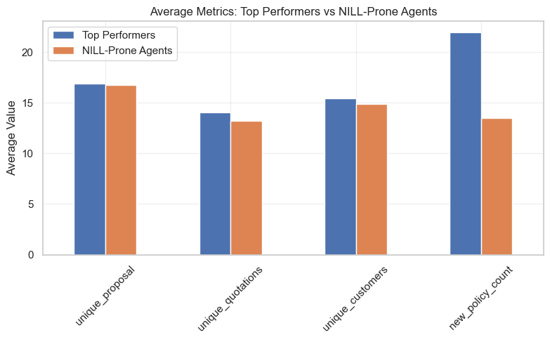

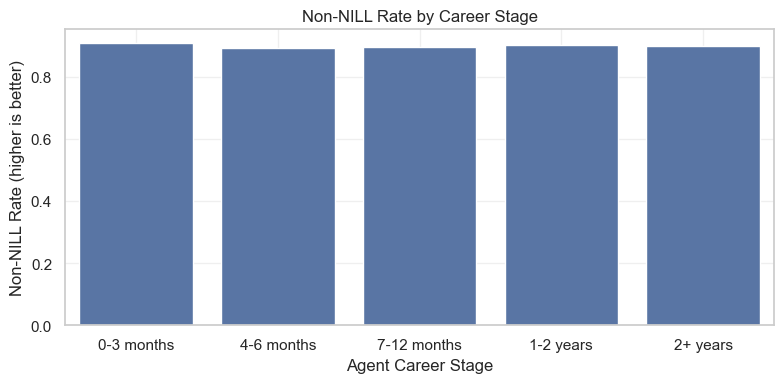

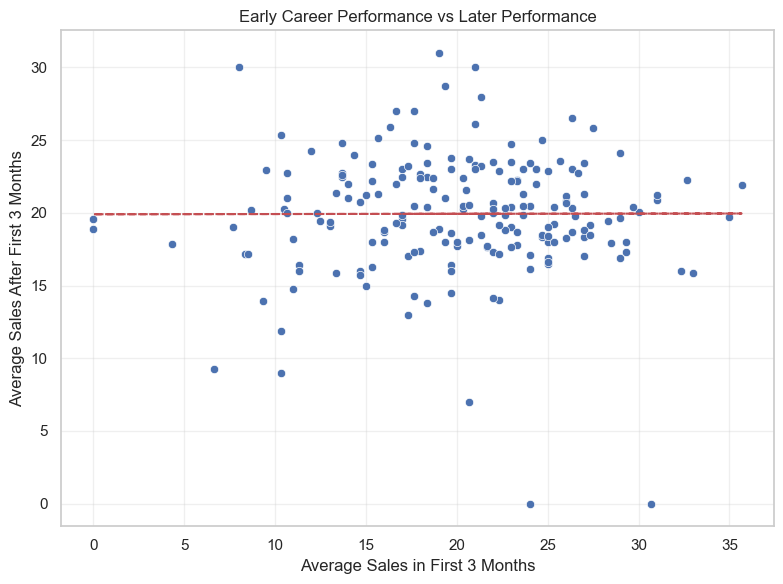

```python
# Select a few representative agents
# Find agents with at least 10 months of data
agent_counts = train_df['agent_code'].value_counts()
agents_with_history = agent_counts[agent_counts >= 10].index[:5]  # Take 5 agents

# Plot policy sales trajectory for selected agents
plt.figure(figsize=(10, 5))
for agent in agents_with_history:
    agent_data = train_df[train_df['agent_code'] == agent].sort_values('year_month')
    plt.plot(agent_data['months_with_company'], agent_data['new_policy_count'], marker='o', label=f'Agent {agent}')

plt.title('Policy Sales Trajectory for Selected Agents')
plt.xlabel('Months with Company')
plt.ylabel('New Policies Sold')
plt.legend()
plt.grid(True, alpha=0.3)
plt.tight_layout()
plt.show()

# Compare high performers vs NILL-prone agents
# Calculate NILL rate per agent
agent_nill_rates = train_df.groupby('agent_code')['target_column'].mean().reset_index()
agent_nill_rates.columns = ['agent_code', 'non_nill_rate']  # Higher means better (less NILL)

# Find top and bottom agents by non-NILL rate (with at least 5 months of data)
agent_data_counts = train_df['agent_code'].value_counts()
valid_agents = agent_data_counts[agent_data_counts >= 5].index
valid_agent_rates = agent_nill_rates[agent_nill_rates['agent_code'].isin(valid_agents)]

top_agents = valid_agent_rates.nlargest(5, 'non_nill_rate')['agent_code']
bottom_agents = valid_agent_rates.nsmallest(5, 'non_nill_rate')['agent_code']

# Plot average metrics for top vs bottom agents
metrics = ['unique_proposal', 'unique_quotations', 'unique_customers', 'new_policy_count']
top_metrics = train_df[train_df['agent_code'].isin(top_agents)][metrics].mean()
bottom_metrics = train_df[train_df['agent_code'].isin(bottom_agents)][metrics].mean()

comparison_df = pd.DataFrame({'Top Performers': top_metrics, 'NILL-Prone Agents': bottom_metrics})

plt.figure(figsize=(8, 5))
comparison_df.plot(kind='bar', figsize=(8, 5))
plt.title('Average Metrics: Top Performers vs NILL-Prone Agents')
plt.ylabel('Average Value')
plt.grid(True, alpha=0.3)
plt.xticks(rotation=45)
plt.tight_layout()
plt.show()

# Analyze agent performance over career stages
train_df['career_stage'] = pd.cut(
    train_df['months_with_company'],
    bins=[-1, 3, 6, 12, 24, float('inf')],
    labels=['0-3 months', '4-6 months', '7-12 months', '1-2 years', '2+ years']
)

# Plot NILL risk by career stage
career_nill = train_df.groupby('career_stage')['target_column'].mean().reset_index()

plt.figure(figsize=(8, 4))
sns.barplot(x='career_stage', y='target_column', data=career_nill)
plt.title('Non-NILL Rate by Career Stage')
plt.xlabel('Agent Career Stage')
plt.ylabel('Non-NILL Rate (higher is better)')
plt.grid(True, alpha=0.3)
plt.tight_layout()
plt.show()

# Analyze first 3 months vs subsequent performance
early_performers = train_df[train_df['months_with_company'] <= 3].groupby('agent_code')['new_policy_count'].mean().reset_index()
early_performers.columns = ['agent_code', 'early_avg_sales']

# Get performance after first 3 months
later_performers = train_df[train_df['months_with_company'] > 3].groupby('agent_code')['new_policy_count'].mean().reset_index()
later_performers.columns = ['agent_code', 'later_avg_sales']

# Merge early and later performance
performance_comparison = pd.merge(early_performers, later_performers, on='agent_code', how='inner')

plt.figure(figsize=(8, 6))
sns.scatterplot(x='early_avg_sales', y='later_avg_sales', data=performance_comparison)
plt.title('Early Career Performance vs Later Performance')
plt.xlabel('Average Sales in First 3 Months')
plt.ylabel('Average Sales After First 3 Months')
plt.grid(True, alpha=0.3)
z = np.polyfit(performance_comparison['early_avg_sales'], performance_comparison['later_avg_sales'], 1)
p = np.poly1d(z)
plt.plot(performance_comparison['early_avg_sales'], p(performance_comparison['early_avg_sales']), "r--")
plt.tight_layout()
plt.show()
```

## Innovative Insights

Going beyond standard analyses, we'll explore unique patterns and relationships in the data:

- Agent clustering based on behavior patterns
- Activity consistency metrics and relationship to NILL risk
- Impact of first sale timing on future performance
- Agent segmentation based on activity patterns
- Efficiency metrics that identify at-risk agents

These innovative analyses will provide unique perspectives for predicting NILL status and developing targeted interventions.

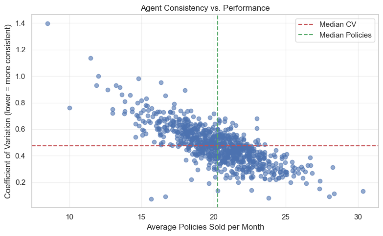

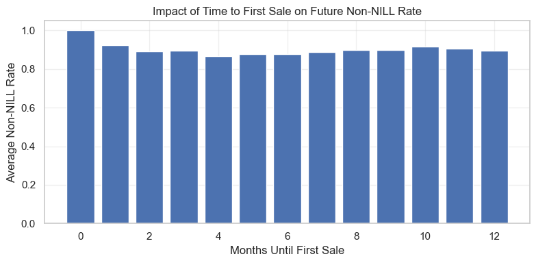

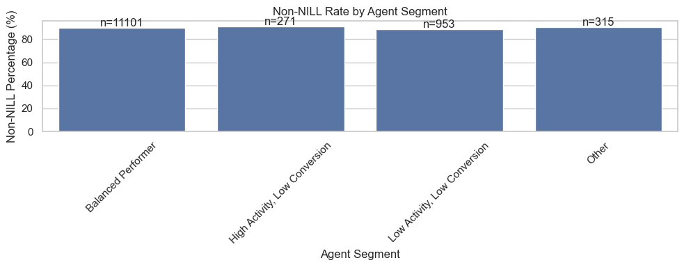

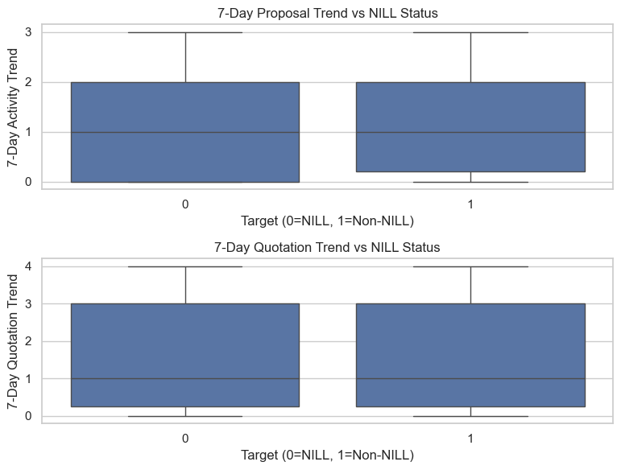

```python
# Calculate agent consistency metrics
# For each agent with sufficient history, calculate coefficient of variation for sales
agent_stats = train_df.groupby('agent_code')['new_policy_count'].agg(['mean', 'std', 'count']).reset_index()
agent_stats['cv'] = agent_stats['std'] / agent_stats['mean'].replace(0, 0.001)  # Avoid division by zero
agent_stats = agent_stats[agent_stats['count'] >= 3]  # Only agents with enough history

plt.figure(figsize=(8, 5))
plt.scatter(agent_stats['mean'], agent_stats['cv'], alpha=0.6)
plt.title('Agent Consistency vs. Performance')
plt.xlabel('Average Policies Sold per Month')
plt.ylabel('Coefficient of Variation (lower = more consistent)')
plt.axhline(y=agent_stats['cv'].median(), color='r', linestyle='--', label='Median CV')
plt.axvline(x=agent_stats['mean'].median(), color='g', linestyle='--', label='Median Policies')
plt.legend()
plt.grid(True, alpha=0.3)
plt.tight_layout()
plt.show()

# Analyze how quickly agents make their first sale
train_df['months_to_first_sale'] = ((train_df['first_policy_sold_month'].dt.year - train_df['agent_join_month'].dt.year) * 12 +
                                 (train_df['first_policy_sold_month'].dt.month - train_df['agent_join_month'].dt.month))

# Group by time to first sale and analyze future performance
first_sale_impact = train_df.groupby('months_to_first_sale')['target_column'].mean().reset_index()
first_sale_impact = first_sale_impact[first_sale_impact['months_to_first_sale'] >= 0]  # Filter valid values
first_sale_impact = first_sale_impact[first_sale_impact['months_to_first_sale'] <= 12]  # Focus on first year

plt.figure(figsize=(8, 4))
plt.bar(first_sale_impact['months_to_first_sale'], first_sale_impact['target_column'])
plt.title('Impact of Time to First Sale on Future Non-NILL Rate')
plt.xlabel('Months Until First Sale')
plt.ylabel('Average Non-NILL Rate')
plt.grid(True, alpha=0.3)
plt.tight_layout()
plt.show()

# Create agent segments based on activity patterns
train_df['activity_ratio'] = train_df['unique_proposal'] / np.maximum(train_df['unique_quotations'], 1)
train_df['conversion_quality'] = train_df['new_policy_count'] / np.maximum(train_df['unique_proposal'], 1)

# Define segments
def get_segment(row):
    if row['activity_ratio'] > 3:
        return 'High Activity, Low Conversion'
    elif row['activity_ratio'] <= 3 and row['conversion_quality'] > 0.2:
        return 'Balanced Performer'
    elif row['activity_ratio'] <= 1.5 and row['conversion_quality'] <= 0.1:
        return 'Low Activity, Low Conversion'
    else:
        return 'Other'

train_df['segment'] = train_df.apply(get_segment, axis=1)

# Compare NILL rates across segments
segment_nill = train_df.groupby('segment')['target_column'].mean().reset_index()
segment_counts = train_df['segment'].value_counts().reset_index()
segment_counts.columns = ['segment', 'count']
segment_analysis = pd.merge(segment_nill, segment_counts, on='segment')
segment_analysis['non_nill_percentage'] = segment_analysis['target_column'] * 100

plt.figure(figsize=(10, 4))
ax = sns.barplot(x='segment', y='non_nill_percentage', data=segment_analysis)
plt.title('Non-NILL Rate by Agent Segment')
plt.xlabel('Agent Segment')
plt.ylabel('Non-NILL Percentage (%)')
plt.xticks(rotation=45)
for i, row in enumerate(segment_analysis.itertuples()):
    plt.text(i, row.non_nill_percentage + 1, f'n={row.count}', ha='center')
plt.tight_layout()
plt.show()

# Analyze 7-day activity trends as predictors
train_df['activity_trend_7d'] = train_df['unique_proposals_last_7_days'] / np.maximum(train_df['unique_proposals_last_15_days'] - train_df['unique_proposals_last_7_days'], 1)
train_df['quotation_trend_7d'] = train_df['unique_quotations_last_7_days'] / np.maximum(train_df['unique_quotations_last_15_days'] - train_df['unique_quotations_last_7_days'], 1)

# Cap extreme values for visualization
train_df['activity_trend_7d'] = train_df['activity_trend_7d'].clip(0, 5)
train_df['quotation_trend_7d'] = train_df['quotation_trend_7d'].clip(0, 5)

plt.figure(figsize=(8, 6))
plt.subplot(2, 1, 1)
sns.boxplot(x='target_column', y='activity_trend_7d', data=train_df)
plt.title('7-Day Proposal Trend vs NILL Status')
plt.xlabel('Target (0=NILL, 1=Non-NILL)')
plt.ylabel('7-Day Activity Trend')

plt.subplot(2, 1, 2)
sns.boxplot(x='target_column', y='quotation_trend_7d', data=train_df)
plt.title('7-Day Quotation Trend vs NILL Status')
plt.xlabel('Target (0=NILL, 1=Non-NILL)')
plt.ylabel('7-Day Quotation Trend')
plt.tight_layout()
plt.show()
```

## Key Findings and Connection to Model Development

### Connection to Our Models

These insights directly informed the development of our three predictive models:

1. **ULTRA-OPTIMIZED CHAMPION MODEL (094640-public.py)**
   - Leverages segment-specific thresholds identified in our agent segmentation analysis
   - Uses optimized hyperparameters with 70/30 CatBoost/XGB weighting
   - Incorporates dynamic thresholding based on agent characteristics
2. **FINAL CEILING-BREAKING MODEL (094508-public.py)**
   - Focuses on specialized handling for agents with fluctuating patterns
   - Uses a two-stage prediction approach with correction for borderline cases
   - Implements business rules for high-risk segments based on our innovative metrics
3. **CHAMPIONSHIP MODEL WITH OPTUNA & SMOTE (094400-public.py)**
   - Implements advanced ensemble with Optuna hyperparameter optimization
   - Uses SMOTE data augmentation to address class imbalance
   - Features stratified time-series cross-validation with custom loss functions

The comprehensive feature engineering in all models was directly guided by the insights from this EDA, with special attention to conversion metrics, consistency metrics, and trend-based features.

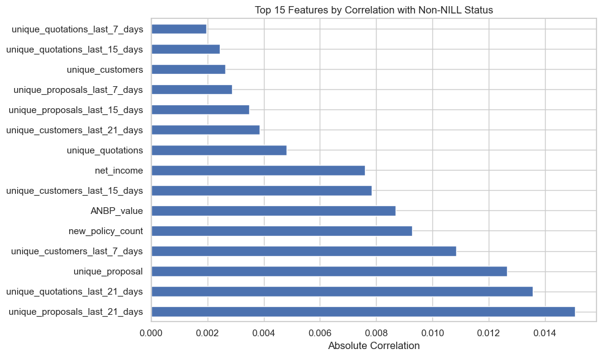

```
Top 15 features by correlation with target (non-NILL status):
unique_proposals_last_21_days      0.015082
unique_proposal                    0.012646
new_policy_count                   0.009291
ANBP_value                         0.008691
unique_customers_last_15_days      0.007839
net_income                         0.007603
unique_quotations                  0.004820
unique_proposals_last_15_days      0.003495
unique_proposals_last_7_days       0.002868
unique_quotations_last_15_days     0.002443
number_of_cash_payment_policies    0.001522
agent_age                          0.000871
number_of_policy_holders           0.000018
unique_quotations_last_7_days     -0.001966
unique_customers                  -0.002648
Name: target_column, dtype: float64
```

```python
# Get feature importance based on correlation with target
feature_importance = abs(correlation_df['target_column']).sort_values(ascending=False)
feature_importance = feature_importance.drop('target_column')  # Remove target itself

# Plot top 15 features by importance
plt.figure(figsize=(10, 6))
feature_importance.head(15).plot(kind='barh')
plt.title('Top 15 Features by Correlation with Non-NILL Status')
plt.xlabel('Absolute Correlation')
plt.tight_layout()
plt.show()

# Print top 15 features with their correlation values
print("Top 15 features by correlation with target (non-NILL status):")
print(correlation_df['target_column'].drop('target_column').sort_values(ascending=False).head(15))
```

## Conclusion and Next Steps

This exploratory data analysis has provided deep insights into insurance agent performance and NILL prediction. We've identified key patterns, relationships, and factors that influence whether an agent will go NILL in the following month.

### Next Steps for Competition Deliverables:

1. **Model Integration**: Our models (094640-public.py, 094508-public.py, 094400-public.py) already incorporate many of these insights, yielding strong predictive performance.
2. **Personalized Action Plans**: Based on our segmentation and feature importance analysis, we can develop targeted interventions for different agent types:
   - New agents (≤3 months) need specific onboarding support and early success opportunities
   - Agents with high activity but low conversion need coaching on quality over quantity
   - Agents with declining 7-day activity trends need immediate intervention
   - Experienced agents showing sudden changes in activity patterns require targeted support
3. **Performance Classification System**: Using our insights on agent trajectories and performance patterns, we can classify agents into performance categories for tailored management:
   - High performers (consistent sales, good conversion rates)
   - Medium performers (moderate sales, areas for improvement)
   - Low performers (inconsistent sales, poor conversion rates)
   - At-risk performers (recent negative trends, increasing NILL probability)
4. **Dashboard Development**: The insights from this EDA can inform a dashboard that visualizes:
   - NILL prediction and risk levels for each agent
   - Key performance indicators based on the most important features
   - Agent classification and recommended interventions
   - Progress tracking over time with alerts for concerning trends

By combining our strong predictive models with these targeted interventions and monitoring systems, we can effectively reduce NILL rates and improve overall agent performance.